# A3: Incarceration

### Introduction

I will be analyzing the racial population data of prisoners. This is because there seems to be a great discrepancy between colored prisoners and white prisoners. Understanding how significant these differences are can massive help in understanding the racial prejudices that exist in our society.

### The Dataset

Who collected the data?

- The US Bureau of Justice Statistics

How was the data collected or generated?

- This data was compiled and generated throughout the years from official records

Why was the data collected?

- This data was collected to look for trends in jail populations for race and gender while also looking at the prison populations compared with their urban/rural data.

How many observations (rows) are in your data?

- 153811 observations

How many features (columns) are in the data?

- 28 features

What, if any, ethical questions or questions of power do you need to consider when working with this data?

- This data can potentially harm stereotypes about certain populations depending on how it’s presented. If this data is unfairly used to compare racial data or manipulated in a way that misinforms the general population it can create a culture which further reinforces what people think about someone based on their traits from birth.

What are possible limitations or problems with this data? (at least 200 words)

- This data doesn’t seem to be as complete as it should be. Although it begins recording data in 1970, for whatever reason, nearly all racial data is left unfilled for several years if not 10+ years. I assume this is because they were only recording specific racial data in the past or only sex based data and it ended up being grouped into this one data set. If instead this data was separated to only show racial data and another data set was created for the other columns I think it could show case a more accurate representation of racial data overall. I believe that due to this issue, the averages of racial data may be heavily skewed to 0’s or to larger numbers for when there is null data. This data set for example has an average incarceration rate for black individuals as much lower than white individuals despite the fact that there have been many protests and informative data analysis done to show that black incarceration rates are higher in each state than white individuals. This data set is also missing data that could show information about the average sentence for different races and the reason they were imprisoned. Without all this information, we are just left with a small piece of a much more complex puzzle.

### Trends Over Time Chart

This chart was made to showcase the average population of jails from 1999 to 2018. This is then separated into colored, each race considered colored and white races to show how it has changed overtime. So far, colored individuals account for a larger percentage of the population in jail than whiten individuals but it does show that white races ALONE account for the largest population between incarcerated races.

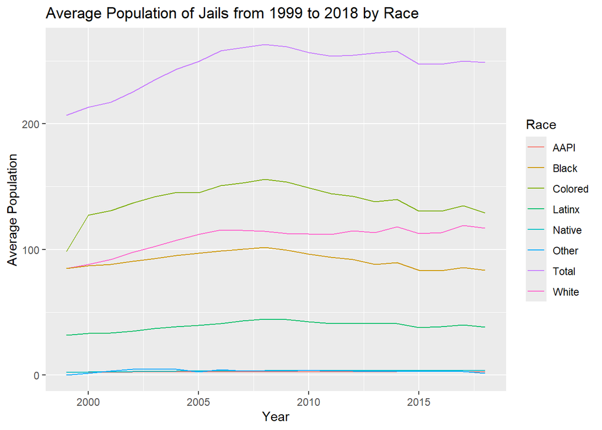

### Variable Comparison Chart

This chart was made to showcase how the average population of colored prisoners has increased / decreased from 1999 to 2018. Instead of it being a comparison between races I wanted to see how colored individual populations in prison have increased over the years. It is somewhat clear that is increased at some point around 2010 but as time has gone on, the amount of colored prisoners seems to have lowered. This could potentially be because of racial injustice protests but there isn’t enough information to conclude that.

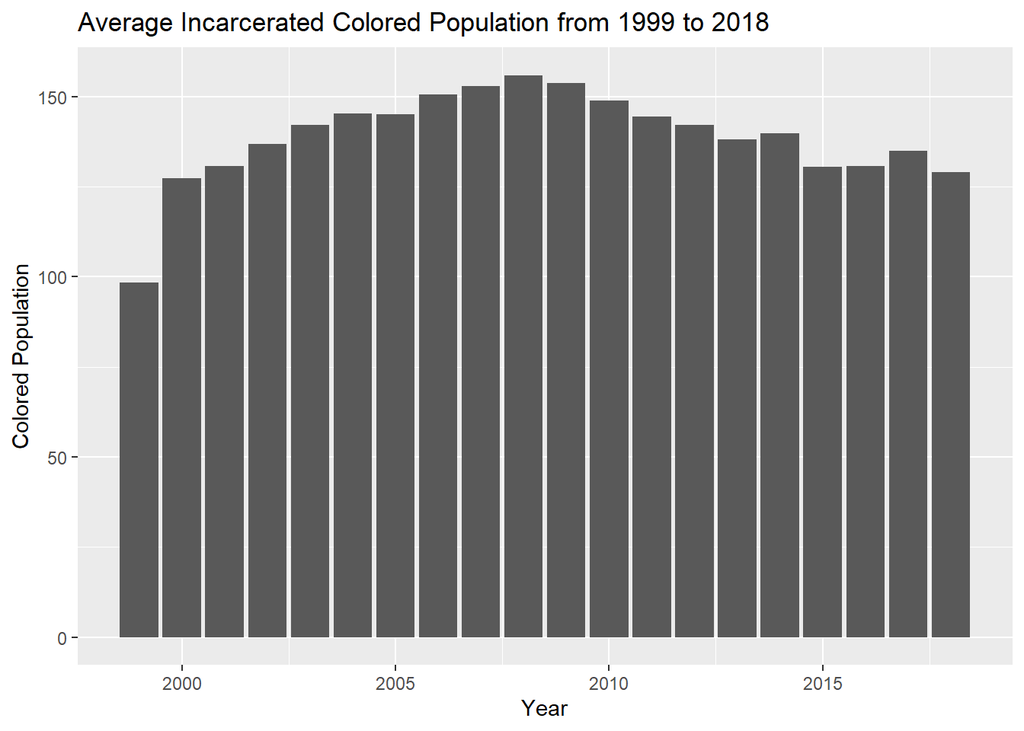

### Map

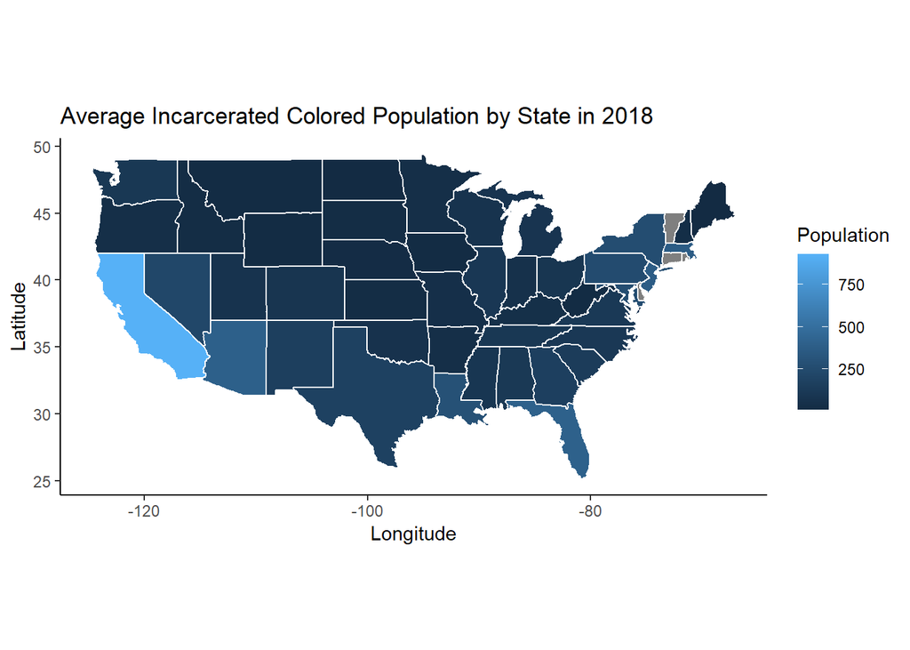